# Tugas Praktikum 5

Atika Fawwaz

2023-10-01

# Library

```r
library(ggplot2)
library(tsibble)
library(tseries)
library(MASS)
library(rio)
```

# Data Coffe Arabica

```r
library(rio)
data <- import("https://raw.githubusercontent.com/atikafawwaz/mpdw/main/Pertemuan%201/coffeprices.xlsx", format = "xlsx")
```

```r
View(data)
str(data)
```

```
## 'data.frame':    100 obs. of  2 variables:
##  $ Date : POSIXct, format: "1960-01-01" "1960-02-01" ...
##  $ Price: num  0.941 0.947 0.928 0.93 0.92 ...
```

```r
dim(data)
```

```
## [1] 100   2
```

```r
# konversi kolom Price menjadi objek time series
data.ts <- ts(data$Price, start = c(1960, 1), frequency = 12)
```

```r
summary(data.ts)
```

```
##    Min. 1st Qu.  Median    Mean 3rd Qu.    Max.
##  0.7970  0.8506  0.9001  0.9063  0.9546  1.0490
```

## Pengujian stasioneritas data dalam Rataan dan Ragam

Pengujian stasioneritas data dilakukan dengan beberapa cara, yaitu: 1. Plot Time Series 2. Plot ACF 3. Uji ADF 4. Plot Box-Cox

### Plot *Time Series*

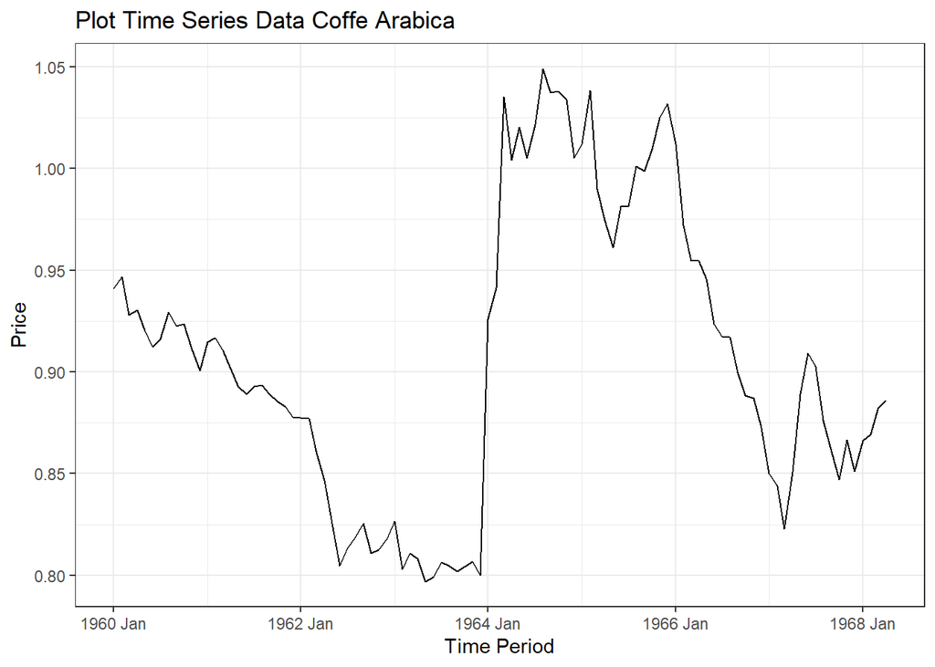

```r
plot_data.ts <- data.ts |> as_tsibble() |>
  ggplot(aes(x = index, y = value)) + geom_line() + theme_bw() +
  xlab("Time Period") + ylab("Price") + ggtitle("Plot Time Series Data Coffe Arabica")
plot_data.ts
```

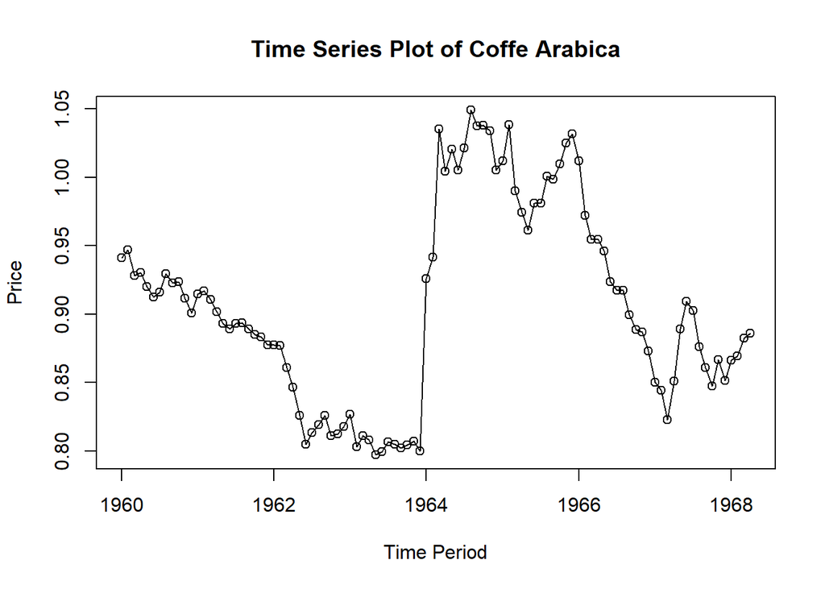

```r
ts.plot(data.ts, xlab="Time Period", ylab="Price",
        main = "Time Series Plot of Coffe Arabica")
points(data.ts)
```

```r
mean(data.ts)
```

```
## [1] 0.906284
```

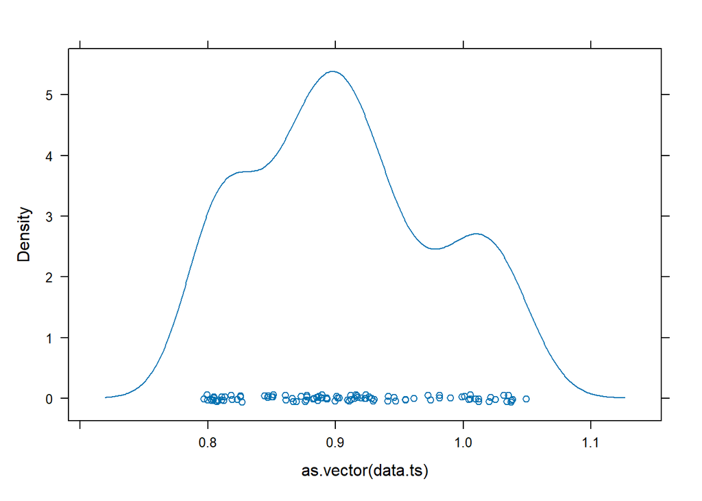

```r
lattice::densityplot(as.vector(data.ts))
```

### Plot ACF

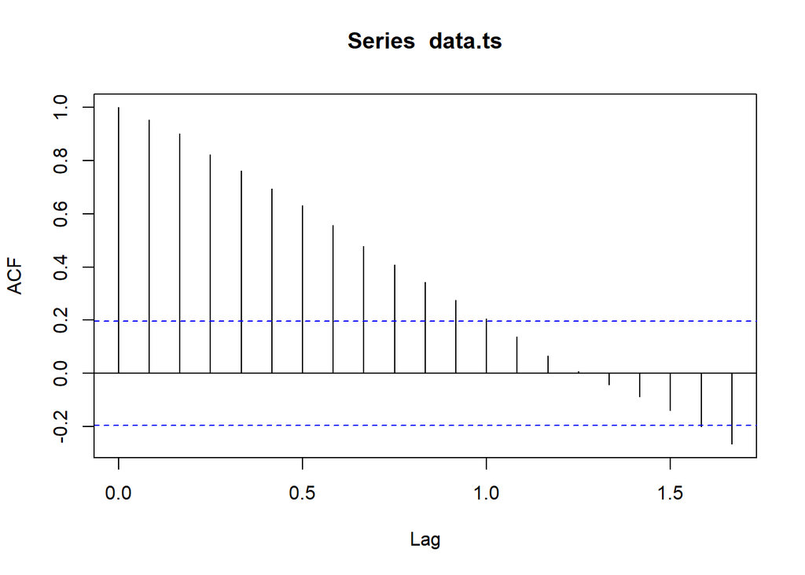

```r
acf(data.ts)
```

Berdasarkan plot ACF, terlihat bahwa pola ACF pada data tersebut cenderung tails off secara perlahan dan membentuk gelombang sinus. Hal ini menunjukkan bahwa asumsi stasioneritas dalam rataan **belum terpenuhi** karena ACF tidak cepat turun menuju nol.

### Uji ADF

```r
tseries::adf.test(data.ts)
```

```
##
##  Augmented Dickey-Fuller Test
##
## data:  data.ts
## Dickey-Fuller = -1.7537, Lag order = 4, p-value = 0.6787
## alternative hypothesis: stationary
```

$H_0$ : Data tidak data.tsioner dalam rataan

$H_1$ : Data data.tsioner dalam rataan

Berdasarkan uji ADF tersebut, didapat *p-value* sebesar 0.6787 yang lebih besar dari taraf nyata 5% sehingga **terima** $H_0$ dan menandakan bahwa data **data tidak stasioner dalam rataan.** Hal ini sesuai dengan hasil eksplorasi menggunakan plot time series dan plot ACF.

### Plot Box-Cox

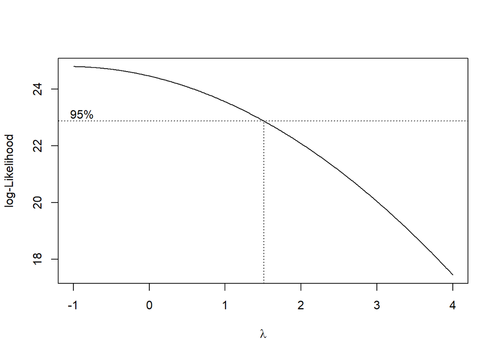

```r
index <- seq(1:100)
bc = boxcox(data.ts~index, lambda = seq(-1,4,by=0.01)) #seq dan
```

```r
#Nilai Rounded Lambda
lambda <- bc$x[which.max(bc$y)]
lambda
```

```
## [1] -1
```

```r
#SK
bc$x[bc$y > max(bc$y) - 1/2 * qchisq(.95,1)]
```

```
##   [1] -1.00 -0.99 -0.98 -0.97 -0.96 -0.95 -0.94 -0.93 -0.92 -0.91 -0.90 -0.89
##  [13] -0.88 -0.87 -0.86 -0.85 -0.84 -0.83 -0.82 -0.81 -0.80 -0.79 -0.78 -0.77
##  [25] -0.76 -0.75 -0.74 -0.73 -0.72 -0.71 -0.70 -0.69 -0.68 -0.67 -0.66 -0.65
##  [37] -0.64 -0.63 -0.62 -0.61 -0.60 -0.59 -0.58 -0.57 -0.56 -0.55 -0.54 -0.53
##  [49] -0.52 -0.51 -0.50 -0.49 -0.48 -0.47 -0.46 -0.45 -0.44 -0.43 -0.42 -0.41
##  [61] -0.40 -0.39 -0.38 -0.37 -0.36 -0.35 -0.34 -0.33 -0.32 -0.31 -0.30 -0.29
##  [73] -0.28 -0.27 -0.26 -0.25 -0.24 -0.23 -0.22 -0.21 -0.20 -0.19 -0.18 -0.17
##  [85] -0.16 -0.15 -0.14 -0.13 -0.12 -0.11 -0.10 -0.09 -0.08 -0.07 -0.06 -0.05
##  [97] -0.04 -0.03 -0.02 -0.01  0.00  0.01  0.02  0.03  0.04  0.05  0.06  0.07
## [109]  0.08  0.09  0.10  0.11  0.12  0.13  0.14  0.15  0.16  0.17  0.18  0.19
## [121]  0.20  0.21  0.22  0.23  0.24  0.25  0.26  0.27  0.28  0.29  0.30  0.31
## [133]  0.32  0.33  0.34  0.35  0.36  0.37  0.38  0.39  0.40  0.41  0.42  0.43
## [145]  0.44  0.45  0.46  0.47  0.48  0.49  0.50  0.51  0.52  0.53  0.54  0.55
## [157]  0.56  0.57  0.58  0.59  0.60  0.61  0.62  0.63  0.64  0.65  0.66  0.67
## [169]  0.68  0.69  0.70  0.71  0.72  0.73  0.74  0.75  0.76  0.77  0.78  0.79
## [181]  0.80  0.81  0.82  0.83  0.84  0.85  0.86  0.87  0.88  0.89  0.90  0.91
## [193]  0.92  0.93  0.94  0.95  0.96  0.97  0.98  0.99  1.00  1.01  1.02  1.03
## [205]  1.04  1.05  1.06  1.07  1.08  1.09  1.10  1.11  1.12  1.13  1.14  1.15
## [217]  1.16  1.17  1.18  1.19  1.20  1.21  1.22  1.23  1.24  1.25  1.26  1.27
## [229]  1.28  1.29  1.30  1.31  1.32  1.33  1.34  1.35  1.36  1.37  1.38  1.39
## [241]  1.40  1.41  1.42  1.43  1.44  1.45  1.46  1.47  1.48  1.49  1.50  1.51
```

Selang tersebut memuat nilai satu sehingga dapat dikatakan bahwa data bangkitan **data stasioner dalam ragam.**

# Penanganan Data Tidak Stasioner dalam Rataan

Penanganan data tidak stasioner dalam rataan dapat dilakukan dengan metode differencing. Berikut adalah langkah-langkahnya: 1. Lakukan differencing orde 1 pada data. 2. Uji stasioneritas pada data hasil differencing dengan plot time series, plot ACF, dan uji ADF.

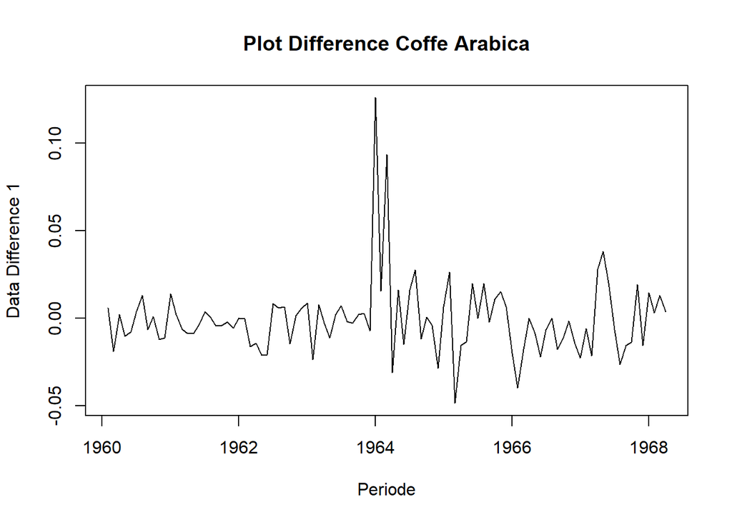

```r
data.diff <- diff(data.ts, differences = 1)
plot.ts(data.diff, lty = 1,
        xlab = "Periode", ylab = "Data Difference 1",
        main = "Plot Difference Coffe Arabica")
```

Pada plot di atas, terlihat bahwa data hasil differencing sudah tidak menunjukkan tren yang jelas sehingga **data sudah stasioner dalam rataan.**

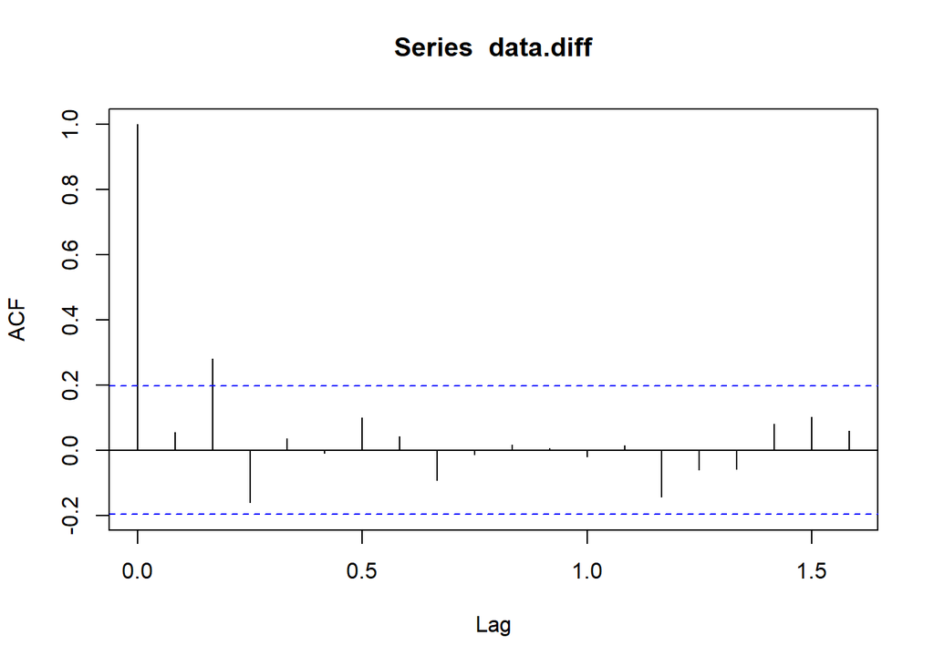

```r
acf(data.diff)
```

```r
tseries::adf.test(data.diff)
```

```
##
##  Augmented Dickey-Fuller Test
##
## data:  data.diff
## Dickey-Fuller = -3.7656, Lag order = 4, p-value = 0.02342
## alternative hypothesis: stationary
```

Berdasarkan uji ADF tersebut, jika diperoleh p-value lebih kecil dari taraf nyata 5%, maka $H_0$ **ditolak** sehingga dapat disimpulkan bahwa **data sudah stasioner dalam rataan.**

**Kesimpulan:** Data Coffe Arabica tidak stasioner dalam rataan, namun sudah stasioner dalam ragam. Setelah dilakukan differencing orde 1, data menjadi stasioner dalam rataan.